# Growth Curve Issues

Erin Campbell

11/20/2020

# The Problem

I have data from a bunch of children with hearing loss who took the CDI. The goal is to have a measure of how “on track” they are with vocabulary development.

To do that, I would like to calculate something like percentile, which we can do for some kids based on norms from hearing children.

However, a big chunk of the sample took the CDI was too old for the version of the CDI administered too them. This is often because the clinician knows that the child is not producing many words, so even if the child is not in the age range for the instrument, they might be in the word range for the instrument.

On this graph, the rainbow lines represent percentiles from hearing children for vocabulary development. Green line = 50th percentile. Each black dot represents a child with hearing loss in our sample. Many of the black dots are outside of the age range of the instrument. For these kids, percentiles are not available.

Instead we generated a growth curve, intended to align with the 50th percentile data from Wordbank. Using this growth curve, we could extract a predicted age given a child’s score. We could then subtract predicted age from chronological age to give us a “months delay” variable. For example, if we expected a child to be 18 months old given their vocabulary, and their chronological age was actually 24, then they would have a 6 month delay. Code for growth curve function below:

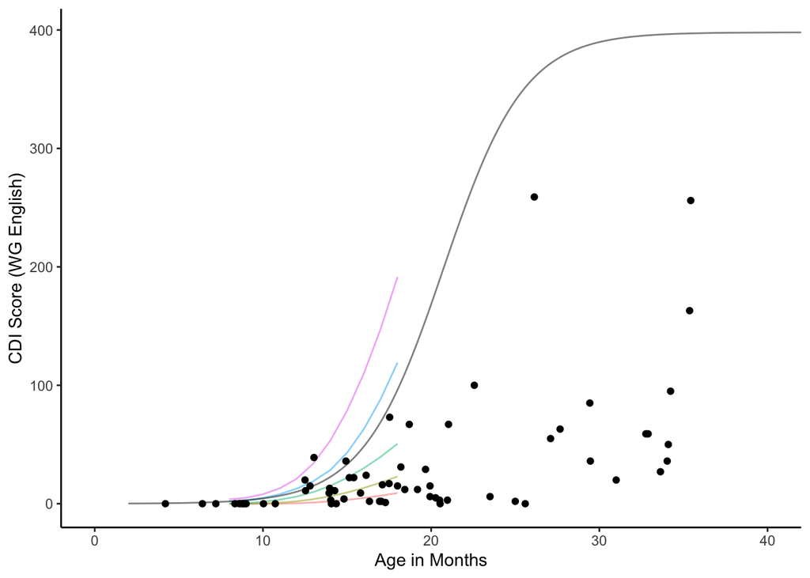

```r
#this function taken from SM_functions.R. Reproducing here for ease of sharing. If you want to make any edits to the function, only do so in SM_functions.R
#big thank you to Stephan Meylan for writing this function
#only showing English function here. Spanish function works in exactly the same way

inv_logit <- function(x){
  return(1 / (exp(-x) + 1))
}

getScoreForAge = function(lm, age, lang, num_items){ #function that takes lm, child's age, and the number of possible words (from WG/WS)
  # just predict
  prop = inv_logit(predict.glm(lm, newdata = data.frame(age=age)))
  return(prop*num_items)
}



getAgeForScore = function(lm, score, num_items){
  proportion = (score + .000001) / num_items #added point .000001 to avoid getting inf delay when score is 0
  # http://www.talkstats.com/threads/inverse-prediction-from-binary-logistic-regression.52121/
  b0 = lm$coefficients[1]
  b1 = lm$coefficients[2]
  predicted_age = (log(proportion / (1-proportion)) - b0)/ b1
  return(predicted_age)
}

constants_eng = list() #create a list called constants
constants_eng[['WG']] = list() #add a WG section to the list
constants_eng[['WG']]$lowest_num_id = 33 #sets the lowest_num_id to 33 (the first question on WG asking 'does your child know X?')
constants_eng[['WG']]$highest_num_id = 430 #sets the highest_num_id to 430 (the last question on WG asking 'does your child know X?')
constants_eng[['WG']]$num_items = constants_eng[['WG']]$highest_num_id - constants_eng[['WG']]$lowest_num_id + 1 #substracts lowest_  and highest_num_ids and adds 1, to get highest possible score on WG
constants_eng[['WS']] = list() #add a WS section to the list
constants_eng[['WS']]$lowest_num_id = 1 #sets the lowest_num_id to 1 (the first question on WS asking 'does your child know X?')
constants_eng[['WS']]$highest_num_id = 680 #sets the highest_num_id to 680 (the last question on WS asking 'does your child know X?')
constants_eng[['WS']]$num_items = constants_eng[['WS']]$highest_num_id - constants_eng[['WS']]$lowest_num_id + 1 #substracts lowest_  and highest_num_ids and adds 1, to get highest possible score on WS

constants_span = list() #create same list for spanish
constants_span[['WG']] = list()
constants_span[['WG']]$lowest_num_id = 1
constants_span[['WG']]$highest_num_id = 428
constants_span[['WG']]$num_items = 428
constants_span[['WS']] = list()
constants_span[['WS']]$lowest_num_id = 1
constants_span[['WS']]$highest_num_id = 680
constants_span[['WS']]$num_items = 680


prepare_elssp_df_eng = function(cdi_form, constants, verbose=F){
  print(paste('Processing ',cdi_form,'...', sep=''))    #Prints "Processing WG..." or WS message

  num_items = constants_eng[[cdi_form]][['num_items']]
  print('Number of items:')
  print(num_items) #Prints number of items possible given CDI version

  eng_data <- get_instrument_data(language = "English (American)", #from wordbankr, gets all administrations for CDI form
                                  form = cdi_form, administrations = TRUE)
  eng_words = subset(eng_data, num_item_id < constants_eng[[cdi_form]][['highest_num_id']] & num_item_id > constants_eng[[cdi_form]][['lowest_num_id']]) #takes the subset of columns related to 'does your child know X word?'

  print('Computing counts...') #Prints "Computing counts" message
  counts <- eng_words %>% #creates counts df
    dplyr::filter(!is.na(.data$age)) %>% #filters entries without an age
    dplyr::mutate(produces = !is.na(.data$value) & .data$value == "produces",
                  understands = !is.na(.data$value) &
                    (.data$value == "understands" | .data$value == "produces")) %>%
    dplyr::select(-.data$value) %>%
    tidyr::gather("measure_name", "value", .data$produces, .data$understands) %>%
    dplyr::filter(.data$measure_name == "produces") %>%
    dplyr::group_by(.data$age, .data$data_id) %>%
    dplyr::summarise(num_true = sum(.data$value),
                     num_false = n() - .data$num_true)
  print(counts)

  print('Fitting model...') #prints "Fitting model" message
  model <- stats::glm(cbind(num_true, num_false) ~ age, counts,
                      family = "binomial")

  if (verbose){ #if verbose argument is TRUE, prints a summary of the model
    print(summary(model))
  }


  new_data = data.frame(age = (seq(2*30.5,48*30.5,by=1) / 30.5), cdi_form)

  print('Getting scores...')

  new_scores = cbind(new_data, data.frame(predict(model, new_data, type='response', se.fit=T)))
  print(names(new_scores))
  new_scores$scores = new_scores$fit * num_items
  new_scores$se_high = new_scores$fit + new_scores$se.fit
  new_scores$se_low = new_scores$fit - new_scores$se.fit
  new_scores$se_high = new_scores$se_high * num_items
  new_scores$se_low = new_scores$se_low * num_items
  new_scores$predict_ages = new_scores$age

  print('Getting Wordbank norms...')
  print(num_items)
  wordbank_norms = read.csv(paste("data/vocabulary_norms_table_",cdi_form,"_Prod",".csv", sep=""),
                            stringsAsFactors=F)

  wordbank_norms_melted = melt(wordbank_norms, id.vars = c("language", "form", "measure", "age", "identity"))

  elssp_for_form <- subset(elssp_eng, CDIversion == cdi_form)
  elssp_for_form$ProductionCDI_no = num_items - elssp_for_form$ProductionCDI
  elssp_for_form$expected_score_at_chron_age = sapply(elssp_for_form$Age,
                                                      function(age){getScoreForAge(model, age, num_items=num_items)})
  elssp_for_form$expected_age_for_score = sapply(elssp_for_form$ProductionCDI,
                                                 function(score){getAgeForScore(model, score, num_items)})

  print('Computing differences...')
  elssp_for_form$diff_score_from_expected = -1 * (elssp_for_form$ProductionCDI - elssp_for_form$expected_score_at_chron_age)
  # more negative, more baf
  elssp_for_form$diff_age_from_expected = elssp_for_form$Age - elssp_for_form$expected_age_for_score

  if (verbose){
    print(elssp_for_form[,c('SubjectNumber','Age',
                            'ProductionCDI', 'expected_score_at_chron_age',
                            'diff_age_from_expected','diff_score_from_expected')])
  }

  print(head(elssp_for_form))
  assign(paste(cdi_form, "elssp_eng", sep = "_"), elssp_for_form, envir = .GlobalEnv)
  assign(paste(cdi_form, "elssp_eng_curves", sep = "_"), wordbank_norms_melted, envir = .GlobalEnv)
  assign(paste(cdi_form, "elssp_eng_gcurve", sep = "_"), new_scores, envir = .GlobalEnv)
}
```

Here, the black line represents the growth curve. The rainbow curves are percentiles from cross-sectional data on wordbank. As you can see, the black curve does not follow the 50th percentile (green). Originally, we had thought this to be a mismatch between the cross-sectional and normative data from Wordbank.

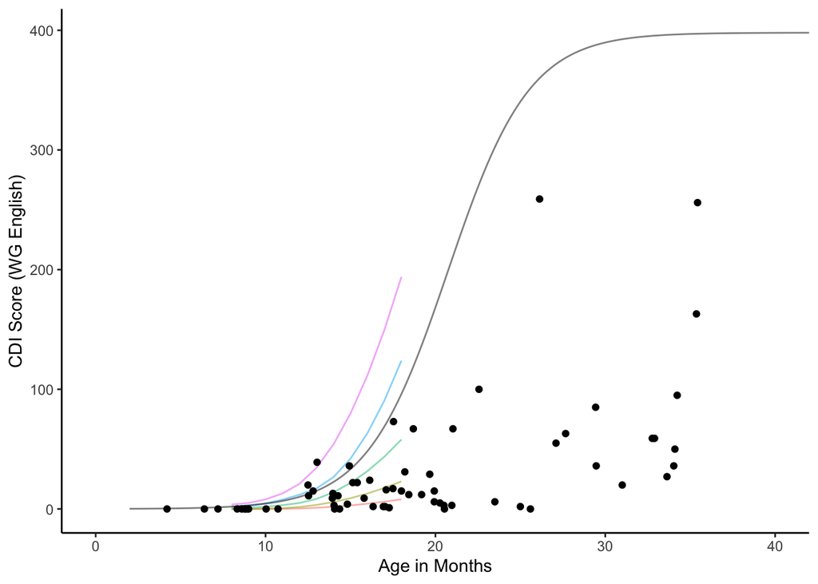

But when plotted against the normative data, it’s clear that the growth curve doesn’t follow those trajectories either.

We generated growth curves separately for Words&Gestures and Words&Sentences for both American English and Mexican Spanish samples. Here are all of these curves (cross-sectional on the left, normative sample on the right).

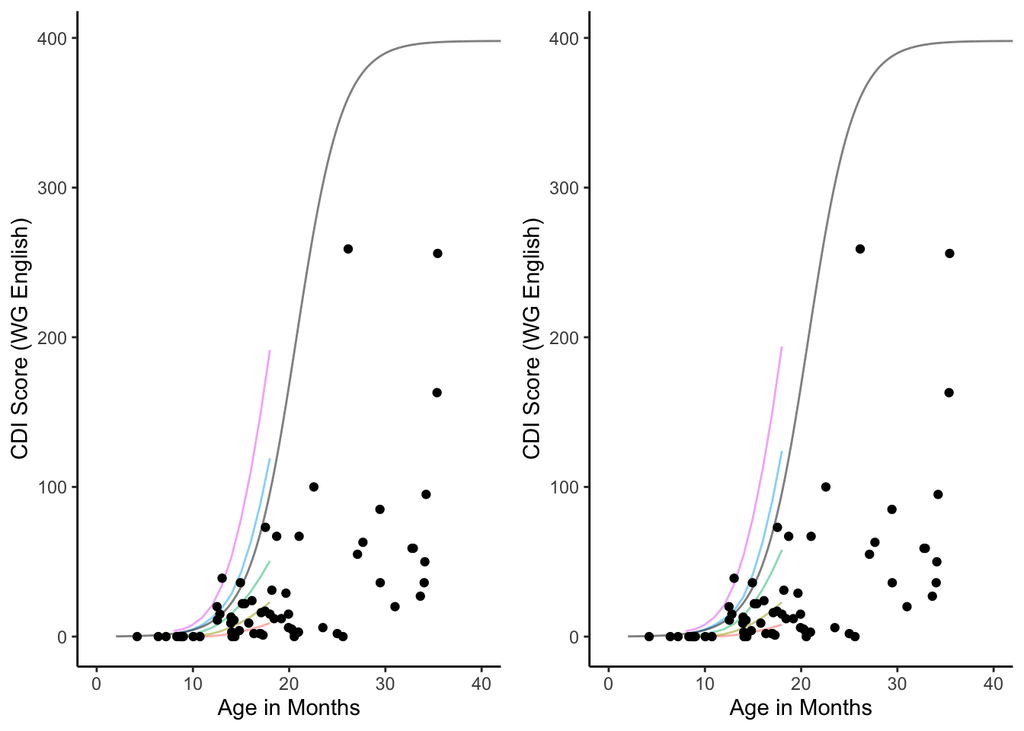

```r
cowplot::plot_grid(cs_WG_eng_curves, nd_WG_eng_curves)
```

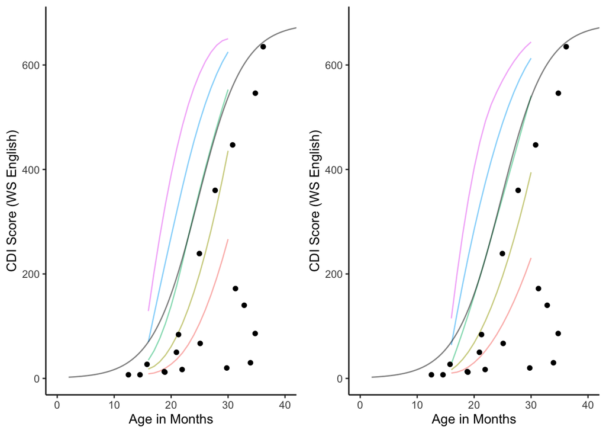

```r
cowplot::plot_grid(cs_WS_eng_curves, nd_WS_eng_curves)
```

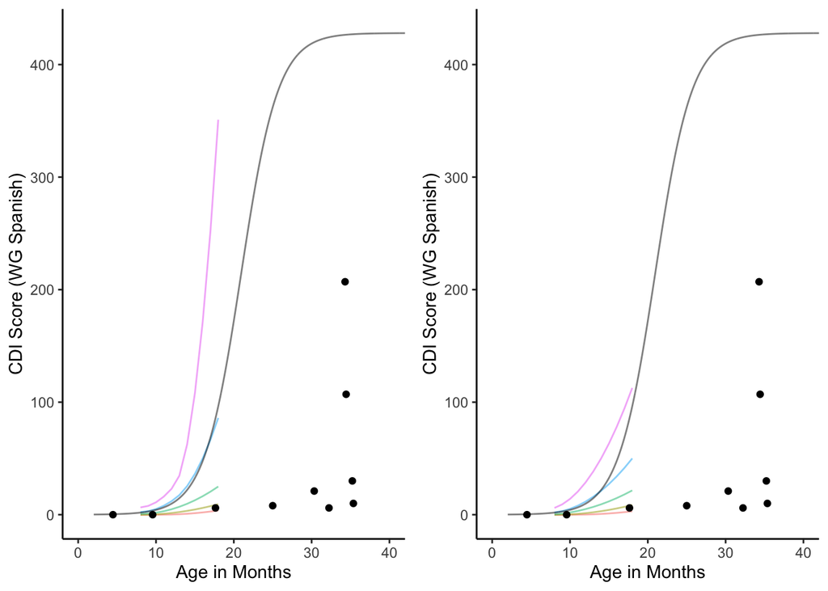

```r
cowplot::plot_grid(cs_WG_span_curves, nd_WG_span_curves)
```

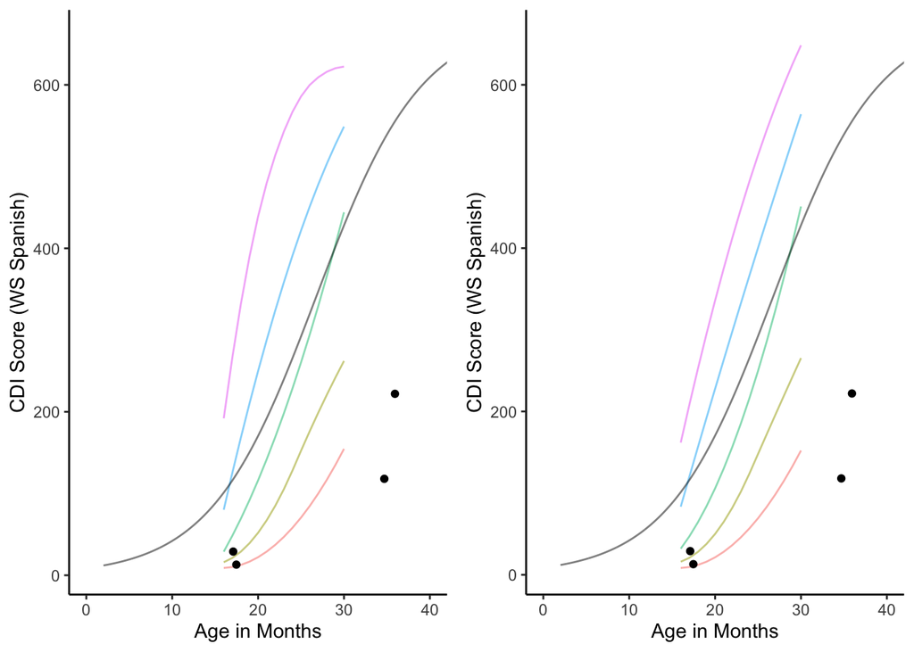

```r
cowplot::plot_grid(cs_WS_span_curves, nd_WS_span_curves)
```

What’s especially obvious on the Spanish language curves is that the curve does not fit the low end of the data well. We know that babies tend to produce their first word around 12 months. Due to some (perhaps optimistic) parents on wordbank, the norms for typically developing kids suggest that they should produce their first words ~8-10 months. But on the growth curve, the x-intercept is way younger than that, suggesting that kids should produce their first word ~4 months, or even -26 months – which we KNOW not to be true.

```r
pre_elssp_curves %>%
  dplyr::select(VIHI_ID, Age, ProductionCDI, CDIversion, diff_age_from_expected) %>%
  arrange(-diff_age_from_expected) %>%
  head(10)
```

```
##       VIHI_ID       Age ProductionCDI CDIversion diff_age_from_expected
## 74 HI_587_779 25.593850             0         WG               52.32854
## 23 HI_526_616 20.533333             0         WG               47.26802
## 78 HI_591_437 14.357525             0         WG               41.09221
## 31 HI_534_422 14.066667             0         WG               40.80136
## 41 HI_546_322 10.733333             0         WG               37.46802
## 26 HI_529_301 10.033333             0         WG               36.76802
## 91 HI_563_287  9.566667             0         WG               35.94120
## 53 HI_561_270  9.000000             0         WG               35.73469
## 30 HI_533_266  8.866667             0         WG               35.60136
## 77 HI_590_267  8.772218             0         WG               35.50691
```

Look at the 8 month olds who are producing 0 words (as 8 month olds should) but are 35 months delayed!

# Solutions?

## Idea 1

The growth curve itself takes data from wordbankr::get_instrument_data, which I believe pulls from a bunch of sources, not just the normative data. One possible next step would be to tinker around with wordbankr and see if we could generate the curves using only the Marchman norming data. Hopefully that curve would fit better?

```r
wordbankr::get_sources(language = "English (American)")
```

```
## # A tibble: 14 x 9
##    source_id name  dataset instrument_lang… instrument_form contributor citation
##        <int> <chr> <chr>   <chr>            <fct>           <chr>       <chr>
##  1         1 Marc… "Normi… English (Americ… Words & Senten… Larry Fens… "Fenson…
##  2         2 Marc… "Wisco… English (Americ… Words & Senten… Virginia M… ""
##  3         3 Marc… "Dalla… English (Americ… Words & Senten… Virginia M… ""
##  4         4 Smith "elect… English (Americ… Words & Senten… Linda Smit… ""
##  5         5 Smith "paper" English (Americ… Words & Senten… Linda Smit… ""
##  6         6 Byers ""      English (Americ… Words & Senten… Krista Bye… ""
##  7         7 Thal  "16"    English (Americ… Words & Senten… Donna Thal… "Thal, …
##  8         8 Thal  "28"    English (Americ… Words & Senten… Donna Thal… "Thal, …
##  9         9 Marc… "Normi… English (Americ… Words & Gestur… Larry Fens… "Fenson…
## 10        10 Byers ""      English (Americ… Words & Gestur… Krista Bye… ""
## 11        11 Thal  "13"    English (Americ… Words & Gestur… Donna Thal… "Thal, …
## 12        12 Thal  "16"    English (Americ… Words & Gestur… Donna Thal… "Thal, …
## 13        36 Frank "xsfac… English (Americ… Words & Gestur… Michael C.… ""
## 14        64 Marc… "Outre… English (Americ… Words & Senten… Anne Ferna… "Ferna…
## # … with 2 more variables: longitudinal <lgl>, license <fct>
```

```r
wordbankr::get_sources(language = "Spanish (Mexican)")
```

```
## # A tibble: 4 x 9
##   source_id name  dataset instrument_lang… instrument_form contributor citation
##       <int> <chr> <chr>   <chr>            <fct>           <chr>       <chr>
## 1        13 Marc… Norming Spanish (Mexica… Words & Senten… Donna Jack… Jackson…
## 2        14 Marc… Norming Spanish (Mexica… Words & Gestur… Donna Jack… Jackson…
## 3        65 Fern… Outrea… Spanish (Mexica… Words & Gestur… Anne Ferna… Weisle…
## 4        66 Fern… Outrea… Spanish (Mexica… Words & Senten… Anne Ferna… Weisle…
## # … with 2 more variables: longitudinal <lgl>, license <fct>
```

## Idea 2

Another option would be to not use the curve for low producing kids. That would mean excluding all kids too young for the instrument (~6) and using some kind of piecewise function to calculate months-delay for kids producing few words. For example, using casewhens:

```r
elssp_curves <- rbind(WG_elssp_eng, WS_elssp_eng, WG_elssp_span, WS_elssp_span) %>%
  filter((Age>8 & CDIversion=='WG')|(Age>16 & CDIversion=='WS')) %>%
  mutate(diff_age_from_expected = case_when( PrimaryLanguage == 'English' & ProductionCDI==0 ~ (Age - 9), #English wordbank data has x-intercept ~9 months
                                             PrimaryLanguage == 'Spanish' & ProductionCDI==0 ~ (Age - 8),
                                             TRUE ~ diff_age_from_expected)) #Spanish wordbank data has x-intercept ~8 months
```

The above code fixes the issue when WordsProduced==0, but as you can see on the Words and Sentences graphs for English and Spanish, the growth curve doesn’t fit well until 100+ words (which would be a lot of casewhens).

```r
elssp_curves %>%
  dplyr::select(VIHI_ID, Age, ProductionCDI, CDIversion, diff_age_from_expected) %>%
  arrange(-diff_age_from_expected) %>%
  head(10)
```

```
##        VIHI_ID      Age ProductionCDI CDIversion diff_age_from_expected
## 1  HI_504_1061 35.36667            10         WG               23.31222
## 2  HI_544_1018 33.93333            30         WS               21.57316
## 3   HI_567_967 32.23333             6         WG               21.41769
## 4  HI_543_1057 35.23333            30         WG               20.44667
## 5  HI_512_1009 33.63333            27         WG               19.17265
## 6   HI_579_893 29.76667            20         WS               19.08988
## 7  HI_509_1021 34.03333            36         WG               18.82401
## 8  HI_507_1023 34.10000            50         WG               18.00847
## 9  HI_594_1058 34.76000            86         WS               17.82563
## 10 HI_593_1056 34.69462           118         WS               17.56452
```

## Idea 3

One additional idea: we could use the 50th percentile line until the max age of the instrument, and only use the growth curve after that. (For Words and Gestures, use the 50th percentile line to calculate delay for children 8-18 months, and for children 18+ months, use the growth curve prediction). The problem there is that Wordbank only has whole-month vocabulary scores, so we don’t have a score associated with say, 50th percentile 16.5-month-olds. So we’d still need some kind of function to generate between-month scores given the wordbank data.